# Data exploration

Florian Bouchet

Packages that will be useful:

```r
# Loading packages
library(dplyr)
library(TCGAbiolinks)
library(SummarizedExperiment)
library(ggplot2)
```

We download the RNA-seq data from the **TCGA-BRCA** project with the following commands (starting with expression data and associated metadata):

##Specifying the project and that we want transcriptomics data, in particular gene expression data (read counts)

#predata <- GDCquery(project = “TCGA-BRCA”, data.category = “Transcriptome Profiling”, data.type = “Gene Expression Quantification”, workflow.type = “STAR - Counts”)

##Best to specify files.per.chunk = 100 so that data is partitioned into smaller chunks that are downloaded separately so that one avoid problems related to file size during download

#GDCdownload(predata, files.per.chunk = 100)

##Creating a RangedSummarizedExperiment from the downloaded data

#data <- GDCprepare(query = predata)

We can save the *RangedSummarizedExperiment* object (*data*):

#save(data, file = “data.rda”)

Now we can load the data directly:

```r
# Loading the expression data
load(file = "data.rda")
# Looking at the data
data
```

```
class: RangedSummarizedExperiment
dim: 60660 1231
metadata(1): data_release
assays(6): unstranded stranded_first ... fpkm_unstrand fpkm_uq_unstrand
rownames(60660): ENSG00000000003.15 ENSG00000000005.6 ...
  ENSG00000288674.1 ENSG00000288675.1
rowData names(10): source type ... hgnc_id havana_gene
colnames(1231): TCGA-GM-A2DL-01A-11R-A18M-07
  TCGA-AC-A2QI-01A-12R-A19W-07 ... TCGA-D8-A1J9-01A-11R-A13Q-07
  TCGA-V7-A7HQ-01A-11R-A33J-07
colData names(97): barcode patient ... paper_PARADIGM Clusters
  paper_Pan-Gyn Clusters
```

```r
# Looking at the first observations and variables in the sample information
# table
head(colData(data), c(5, 5))
```

```
DataFrame with 5 rows and 5 columns
                                            barcode      patient
                                        <character>  <character>
TCGA-GM-A2DL-01A-11R-A18M-07 TCGA-GM-A2DL-01A-11R.. TCGA-GM-A2DL
TCGA-AC-A2QI-01A-12R-A19W-07 TCGA-AC-A2QI-01A-12R.. TCGA-AC-A2QI
TCGA-A8-A06R-01A-11R-A00Z-07 TCGA-A8-A06R-01A-11R.. TCGA-A8-A06R
TCGA-EW-A1PD-01A-11R-A144-07 TCGA-EW-A1PD-01A-11R.. TCGA-EW-A1PD
TCGA-AO-A12D-01A-11R-A115-07 TCGA-AO-A12D-01A-11R.. TCGA-AO-A12D
                                       sample shortLetterCode
                                  <character>     <character>
TCGA-GM-A2DL-01A-11R-A18M-07 TCGA-GM-A2DL-01A              TP
TCGA-AC-A2QI-01A-12R-A19W-07 TCGA-AC-A2QI-01A              TP
TCGA-A8-A06R-01A-11R-A00Z-07 TCGA-A8-A06R-01A              TP
TCGA-EW-A1PD-01A-11R-A144-07 TCGA-EW-A1PD-01A              TP
TCGA-AO-A12D-01A-11R-A115-07 TCGA-AO-A12D-01A              TP
                                      definition
                                     <character>
TCGA-GM-A2DL-01A-11R-A18M-07 Primary solid Tumor
TCGA-AC-A2QI-01A-12R-A19W-07 Primary solid Tumor
TCGA-A8-A06R-01A-11R-A00Z-07 Primary solid Tumor
TCGA-EW-A1PD-01A-11R-A144-07 Primary solid Tumor
TCGA-AO-A12D-01A-11R-A115-07 Primary solid Tumor
```

We have 60660 genes for 1231 samples. There are several assays with read counts and the first one compiles the unstranded raw counts. The two following compiles the stranded raw counts, forward (stranded_first) and reverse (stranded_second), respectively.

Now we download the supplementary clinical information that, among others, compiles the information we are interested in: the immunohistochemistry (IHC) data:

##The BCR xml format is best for not encountering problems during download

#preclindata <- GDCquery(project = “TCGA-BRCA”, data.category = “Clinical”, data.type = “Clinical Supplement”, data.format = “BCR xml”)

#GDCdownload(preclindata, files.per.chunk = 100)

#clindata <- GDCprepare_clinic(query = preclindata, clinical.info = “patient”)

We can save the resulting table (*clindata*):

#save(clindata, file = “clindata.rda”)

Now we can load the table directly:

```r
# Loading the supplementary clinical information
load(file = "clindata.rda")
# Looking at the first observations and variables
head(clindata, c(5, 5))
```

```
  bcr_patient_barcode additional_studies tumor_tissue_site
1        TCGA-3C-AAAU                               Breast
2        TCGA-3C-AALI                               Breast
3        TCGA-3C-AALJ                               Breast
4        TCGA-3C-AALK                               Breast
5        TCGA-4H-AAAK                               Breast
  tumor_tissue_site_other other_dx
1                      NA       No
2                      NA       No
3                      NA       No
4                      NA       No
5                      NA       No
```

```r
# Dimensions of the table
dim(clindata)
```

```
[1] 1097  114
```

Here we only have information on 1097 samples. We need to process the data. First of all, in the *data* object, we only keep samples that correspond to primary tumors:

```r
# Selecting samples corresponding to primary tumors only
data <- data[, colData(data)$definition == "Primary solid Tumor"]
```

Exploring the data further we can see that there are sometimes several samples for a same patient. We select the first sample only, for each patient:

```r
# Selecting only the first sample for each patient
data <- data[, !duplicated(colData(data)$patient)]
```

Now we can keep only those patients in the expression data that are represented in the clinical table:

```r
# Selecting only samples in the expression data that appear in the clinical
# table
data <- data[, colData(data)$patient %in% clindata$bcr_patient_barcode]
data
```

```
class: RangedSummarizedExperiment
dim: 60660 1094
metadata(1): data_release
assays(6): unstranded stranded_first ... fpkm_unstrand fpkm_uq_unstrand
rownames(60660): ENSG00000000003.15 ENSG00000000005.6 ...
  ENSG00000288674.1 ENSG00000288675.1
rowData names(10): source type ... hgnc_id havana_gene
colnames(1094): TCGA-GM-A2DL-01A-11R-A18M-07
  TCGA-AC-A2QI-01A-12R-A19W-07 ... TCGA-D8-A1J9-01A-11R-A13Q-07
  TCGA-V7-A7HQ-01A-11R-A33J-07
colData names(97): barcode patient ... paper_PARADIGM Clusters
  paper_Pan-Gyn Clusters
```

Now we have 1094 samples, corresponding to 1094 different patients. Still, three more samples appear in the clinical table. We remove them:

```r
# keeping only samples in the clinical table that appear in the expression data
clindata <- clindata[clindata$bcr_patient_barcode %in% colData(data)$patient, ]
# Reordering the samples in the clinical table to stick to the order of the
# expression data
clindata <- clindata[order(match(clindata$bcr_patient_barcode, colData(data)$patient)),
    ]
# Verifying that number of samples selected and order is similar
identical(clindata$bcr_patient_barcode, colData(data)$patient)
```

```
[1] TRUE
```

Now we can start with the preliminar exploration. We see that the variables *breast_carcinoma_estrogen_receptor_status* and *er_level_cell_percentage_category* describe the ER status and level, respectively. We can rename these variables and look at their values:

```r
# Renaming the two variables of the clinical table that corresponds to ER
# status and level
clindata <- clindata %>%
    dplyr::rename(ER_status = breast_carcinoma_estrogen_receptor_status, ER_level = er_level_cell_percentage_category)

# Levels of 'ER_status'
levels(clindata$ER_status)
```

```
[1] ""              "Indeterminate" "Negative"      "Positive"
```

```r
# Levels of 'ER_level'
levels(clindata$ER_level)
```

```
 [1] ""       "<10%"   "10-19%" "20-29%" "30-39%" "40-49%" "50-59%" "60-69%"
 [9] "70-79%" "80-89%" "90-99%"
```

We have missing values (NA, blank cases) for both variables. We also have two cases of indeterminate status. Though the NAs are true unreported values while an indeterminate status simply indicates a lack of certainty, we can pool both the NAs and the indeterminate values under “Indeterminate” since all those cases also have an unspecified level (NA), and thus will not be used further (they are no informative). There is only one exception, a case that shows and indeterminate status but that belongs to the “20-29%” ER level category: there is no apparent reason to be uncertain of it positivity since its level is not even at the boundary between positive and negative status so we can leave it as it is. As for the level, we can rename the NAs as “Unspecified” cases. Both “Indeterminate” and “Unspecified” cases will not be considered in downstream analyses (except the single case mentionned just above). But it is best to keep all data, separating them into meaningful categories.

```r
# Renaming the NAs and transforming to factor
clindata <- clindata %>% mutate(
  # Renaming the NAs to "Indeterminate" in the status variable
  ER_status=if_else(ER_status=="", "Indeterminate", ER_status),
  ER_status=factor(ER_status, levels = c("Negative", "Positive", "Indeterminate"))# Important to reorder the factor levels
  ,
  # Renaming the NAs to "Unspecified" in the level variable
  ER_level=if_else(ER_level=="", "Unspecified", ER_level),
  ER_level=as.factor(ER_level)# No need to reorder here
  )
```

We can save the clean data (the *RangedSummarizedExperiment* called *data*) and clean clinical table (*clindata*):

#save(data, file = “dataclean.rda”)

#save(clindata, file = “clindataclean.rda”)

Now we can load them directly:

```r
# Loading the clean expression data
load(file = "dataclean.rda")
# Looking at the data
data
```

```
class: RangedSummarizedExperiment
dim: 60660 1094
metadata(1): data_release
assays(6): unstranded stranded_first ... fpkm_unstrand fpkm_uq_unstrand
rownames(60660): ENSG00000000003.15 ENSG00000000005.6 ...
  ENSG00000288674.1 ENSG00000288675.1
rowData names(10): source type ... hgnc_id havana_gene
colnames(1094): TCGA-GM-A2DL-01A-11R-A18M-07
  TCGA-AC-A2QI-01A-12R-A19W-07 ... TCGA-D8-A1J9-01A-11R-A13Q-07
  TCGA-V7-A7HQ-01A-11R-A33J-07
colData names(97): barcode patient ... paper_PARADIGM Clusters
  paper_Pan-Gyn Clusters
```

```r
# Loading the clean clinical table
load(file = "clindataclean.rda")
```

We can take a look at some biological/social information about the patients included:

```r
# Age
table(clindata$age_at_initial_pathologic_diagnosis)
```

```
26 27 28 29 30 31 32 33 34 35 36 37 38 39 40 41 42 43 44 45 46 47 48 49 50 51
 2  1  1  6  2  3  2  1 10  7  9  7 11 13 22 18 12 16 16 27 28 26 29 26 34 31
52 53 54 55 56 57 58 59 60 61 62 63 64 65 66 67 68 69 70 71 72 73 74 75 76 77
28 24 34 23 33 17 30 32 21 36 51 37 25 23 26 21 23 21 19 20 14 18 16 13 13 13
78 79 80 81 82 83 84 85 86 87 88 89 90
14 18 17  7  6  5 10  5  1  3  5  3  9
```

```r
# Sex
table(clindata$gender)
```

```
FEMALE   MALE
  1082     12
```

```r
# Race
table(clindata$race_list)
```

```
                                 AMERICAN INDIAN OR ALASKA NATIVE
                              95                                1
                           ASIAN        BLACK OR AFRICAN AMERICAN
                              61                              183
                           WHITE
                             754
```

We generate a contingency table as well as a bar chart to see the frequency distribution of both variables of interest (ER level and status):

```r
# Contingency table
table(ESTROGEN_STATUS = clindata$ER_status, ESTROGEN_LEVEL = clindata$ER_level)
```

```
               ESTROGEN_LEVEL
ESTROGEN_STATUS <10% 10-19% 20-29% 30-39% 40-49% 50-59% 60-69% 70-79% 80-89%
  Negative        54      0      0      0      0      0      0      0      0
  Positive        17     25      6      7      8     15     12     49     31
  Indeterminate    0      0      1      0      0      0      0      0      0
               ESTROGEN_LEVEL
ESTROGEN_STATUS 90-99% Unspecified
  Negative           0         183
  Positive         244         393
  Indeterminate      0          49
```

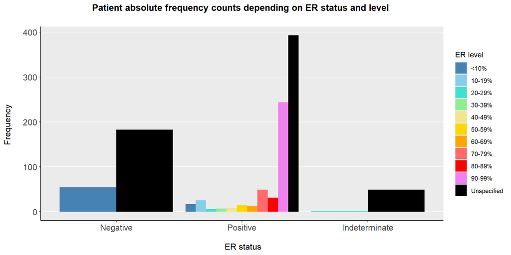

```r
# Barplot
ggplot(clindata, aes(x = ER_status, fill = ER_level)) + geom_bar(position = "dodge") +
    labs(x = "\n ER status", y = "Frequency \n", title = "Patient absolute frequency counts depending on ER status and level \n",
        fill = "ER level") + scale_fill_manual(values = c("steelblue", "skyblue",
    "turquoise", "lightgreen", "khaki", "gold", "orange", "indianred1", "red", "violet",
    "black")) + theme_gray() + theme(panel.grid.major.x = element_blank(), panel.grid.minor = element_blank(),
    axis.line = element_line(color = "black"), plot.title = element_text(face = "bold",
        hjust = 0.5), axis.text = element_text(size = 12), axis.title = element_text(size = 12))
```

One important consideration is that before 2020 all those tumors with ER level inferior to 10% were considered ER-negative tumors, so that there was no need to separate the “<1%” category (0% category; nowadays considered true negative tumors) from the “1-9%” category (nowadays considered ER-low-positive tumors). Here we can see that the tumors with level “<10%” have either a positive or a negative status, implying that the 54 reported as negative are most probably true negative tumors (ER level of <1%/0%) whereas the 17 reported as positive are most probably tumors with ER level of 1-9%! Otherwise, we notice that all tumors with ER level >10% are reported as positive tumors, which is what would be expected. We leave the unspecified cases in their own category.

Based on these considerations we can generate a new variable for ER level using a classification in four categories (as in Voorwerk et al., 2023 but without the “>99%” category since here there is no such level): “<1%”, “1-9%”, “10-50%”, y “>50%”:

```r
# New variable for the ER level
estrogen_level <- case_when(clindata$ER_level %in% levels(clindata$ER_level)[6:10] ~
    ">50%", clindata$ER_level %in% levels(clindata$ER_level)[2:5] ~ "10-50%", clindata$ER_level ==
    "<10%" & clindata$ER_status == "Positive" ~ "1-9%", clindata$ER_level == "<10%" &
    clindata$ER_status == "Negative" ~ "<1%", .default = clindata$ER_level)

# Converting the variable to factor
estrogen_level <- factor(estrogen_level, levels = c("<1%", "1-9%", "10-50%", ">50%",
    "Unspecified"))
```

We generate again the contingency table and bar chart:

```r
# Contingency table
table(ESTROGEN_STATUS = clindata$ER_status, ESTROGEN_LEVEL = estrogen_level)
```

```
               ESTROGEN_LEVEL
ESTROGEN_STATUS <1% 1-9% 10-50% >50% Unspecified
  Negative       54    0      0    0         183
  Positive        0   17     46  351         393
  Indeterminate   0    0      1    0          49
```

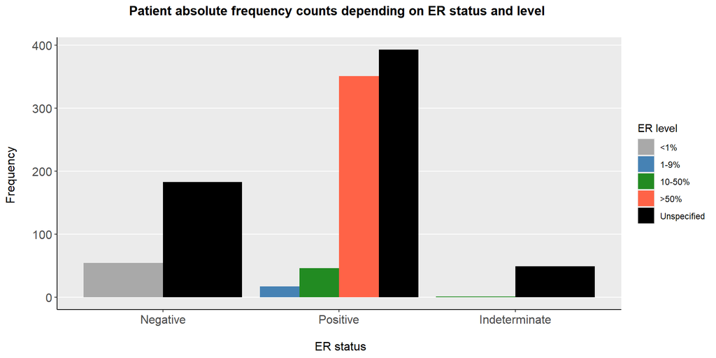

```r
# Barplot
ggplot(clindata, aes(x = ER_status, fill = estrogen_level)) + geom_bar(position = "dodge") +
    labs(x = "\n ER status", y = "Frequency \n", title = "Patient absolute frequency counts depending on ER status and level \n",
        fill = "ER level") + scale_fill_manual(values = c("darkgray", "steelblue",
    "forestgreen", "tomato", "black")) + theme_gray() + theme(panel.grid.major.x = element_blank(),
    panel.grid.minor = element_blank(), axis.line = element_line(color = "black"),
    plot.title = element_text(face = "bold", hjust = 0.5), axis.text = element_text(size = 12),
    axis.title = element_text(size = 12))
```

The results seem correct.

Next, we will explore the distribution of ER expression using the ESR1 (read counts). Read counts will be normalized using the TMM method to eliminate biases due to library size differences, and further using the log2 CPM transformation so that the adjusted counts are scaled. First, we must check the read proportions for the stranded first and second assays to verify if the original libraries used for sequencing were stranded or unstranded.

In a few online Biostars forums some users affirm that unstranded libraries were used for the TCGA-BRCA project (also TCGA data in general). The TCGA program started in 2006 and it seems that RNA-seq data for the TCGA-BRCA project were generated before 2012; at that time using stranded libraries, especially reverse stranded ones, was not common yet. Finally, the GDC user guide never specifies the type of libraries used, just that the STAR count pipeline always generates stranded counts, implying that even for originally unstranded counts the stranded assays will be computed. In any case, the GDC user guide considers all reads as unstranded for the STAR count pipeline. It seems that TCGA-BRCA RNA-seq data were generated using unstranded libraries but it is important to be sure of it as it can have some impact on the downstream analyses:

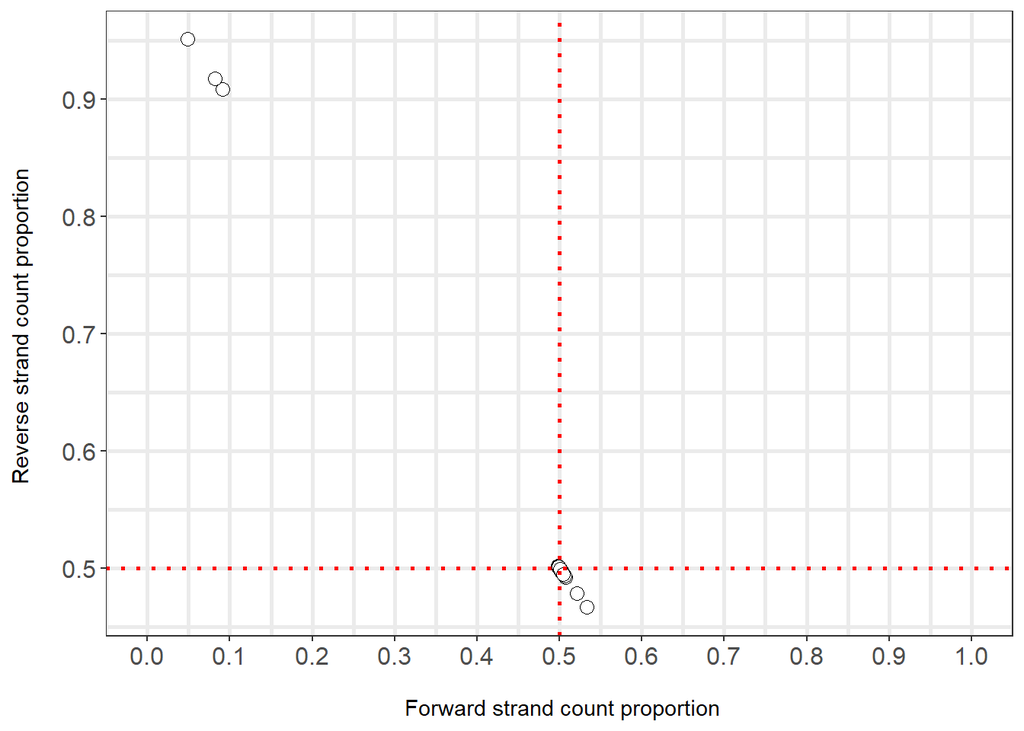

```r
# Read counts for each strand (for each sample) For each sample the read count
# of all genes are added up so that the total read count for each sample is
# obtained
strand1 <- colSums(assay(data, "stranded_first"))
strand2 <- colSums(assay(data, "stranded_second"))
# Total count (both strands) for each sample
totalcounts <- strand1 + strand2
# Bivariate plot using proportion of read counts of each strand
ggplot() + geom_point(aes(x = strand1/totalcounts, y = strand2/totalcounts), shape = 21,
    size = 3, color = "black", fill = "white") + coord_cartesian(xlim = c(0, 1)) +
    geom_hline(yintercept = 0.5, colour = "red", linetype = "dotted", linewidth = 1) +
    geom_vline(xintercept = 0.5, colour = "red", linetype = "dotted", linewidth = 1) +
    labs(x = "\n Forward strand count proportion", y = "Reverse strand count proportion \n") +
    theme_bw() + theme(panel.grid.minor = element_line(linewidth = 1), panel.grid.major = element_line(linewidth = 1),
    axis.text = element_text(size = 12)) + scale_x_continuous(breaks = seq(0, 1,
    0.1)) + scale_y_continuous(breaks = seq(0, 1, 0.1))
```

```r
# Number of outliers (being restrictive)
table((strand1/totalcounts > 0.55 | strand1/totalcounts < 0.45) | (strand2/totalcounts >
    0.55 | strand2/totalcounts < 0.45))
```

```
FALSE  TRUE
 1090     4
```

What we see is that 1090 out of 1094 samples show equal read count proportions among the two strands, that is to say that in 99.6% of the samples about 50% of reads map to each strand, which is consistent with unstranded RNA-seq. Only four are considered outliers and most probably result from technical/processing artifacts. This is not a problem since it appears that these data were indeed originally unstranded.

Now we can proceed to the next step of normalizing and exploring ESR1 expression:

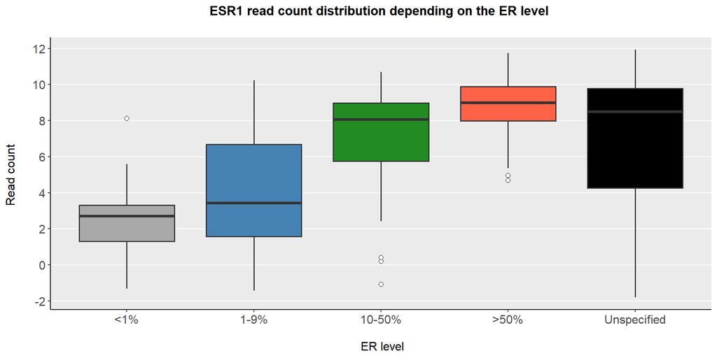

```r
# Creating a DGEList object with normalization factors
listdge <- edgeR::DGEList(assay(data))
listdge <- edgeR::calcNormFactors(listdge, method = "TMM")

# We can save this object (*listdge*) save(listdge, file='listdge.rda')

# Creating a variable with the normalized reads for ESR1
countsfiltrnorm <- edgeR::cpm(listdge, log = T)[rownames(data)[grep("ENSG00000091831",
    rownames(data))], ]

# Table with variables of interest
countsER <- data.frame(counts = countsfiltrnorm, ER_level = estrogen_level)

# We can save this table (*countsER*) save(countsER, file='countsER.rda')

# Boxplots of ESR1 depending on the ER level
ggplot(countsER, aes(x = ER_level, y = counts)) + geom_boxplot(fill = c("darkgray",
    "steelblue", "forestgreen", "tomato", "black"), linewidth = 0.7, outlier.shape = 21,
    outlier.size = 2, outlier.color = "black", outlier.fill = "white") + labs(x = "\n ER level",
    y = "Read count \n", title = "ESR1 read count distribution depending on the ER level \n") +
    theme_gray() + theme(panel.grid.major.x = element_blank(), panel.grid.minor = element_blank(),
    axis.line = element_line(color = "black"), plot.title = element_text(face = "bold",
        hjust = 0.5), axis.text = element_text(size = 12), axis.title = element_text(size = 12)) +
    scale_y_continuous(breaks = seq(-2, 12, 2))
```

We observe that the distribution of counts for the ESR1 gene matches relatively well with ER level. Samples with ER- tumors have a distribution with low median while samples with ER+ tumors generally have higher counts. Regarding the ER level, the general trend is that the more counts the higher the ER level. But there is great variation and some outliers. Leaving aside the “<1%” and “Unspecified” categories, the higher the ER level, the less variance there is in the counts. Therefore, the variance is highest in the “1-9%” category. It might be due to the respective sample size since in that case the higher the ER level, the larger the sample size.

We can test whether there are significant differences between the different ER level categories (omiting the “Unspecified”). We start with an ANOVA.

```r
# ANOVA model
model <- lm(countsER$counts[countsER$ER_level != "Unspecified"] ~ countsER$ER_level[countsER$ER_level !=
    "Unspecified"])

# Checking if residuals deviate from a normal distribution or no
shapiro.test(model$residuals)
```

```
    Shapiro-Wilk normality test

data:  model$residuals
W = 0.97037, p-value = 3.875e-08
```

The residuals indeed deviate from a normal distribution (p-value highly significant), so we will apply a non-parametric Kruskal-Wallis test:

```r
# Kruskal-Wallis test
kruskal.test(countsER$counts[countsER$ER_level != "Unspecified"] ~ countsER$ER_level[countsER$ER_level !=
    "Unspecified"])
```

```
    Kruskal-Wallis rank sum test

data:  countsER$counts[countsER$ER_level != "Unspecified"] by countsER$ER_level[countsER$ER_level != "Unspecified"]
Kruskal-Wallis chi-squared = 166.95, df = 3, p-value < 2.2e-16
```

The test is highly significant (p-value < 2.2e-16) indicating global among group differences. We keep going with post-hoc test, here using Dunn’s test (with Bonferroni correction).

```r
# Paired Dunn's test
dunn.test::dunn.test(countsER$counts[countsER$ER_level != "Unspecified"], countsER$ER_level[countsER$ER_level !=
    "Unspecified"], method = "Bonferroni")
```

```
  Kruskal-Wallis rank sum test

data: x and group
Kruskal-Wallis chi-squared = 166.9461, df = 3, p-value = 0

                           Comparison of x by group
                                 (Bonferroni)
Col Mean-|
Row Mean |        <1%       >50%       1-9%
---------+---------------------------------
    >50% |  -11.93724
         |    0.0000*
    1-9% |  -1.638164   5.191931
         |     0.3042    0.0000*
  10-50% |  -5.443377   4.243119  -2.227064
         |    0.0000*    0.0001*     0.0778

alpha = 0.05
Reject Ho if p <= alpha/2
```

The “>50%” category significantly differs from every other category. The “10-50%” category also differs from the “<1%” category. The “1-9%” category doesn’t differ from the “<1%” category nor the “10-50%” one. It can be explicated by the high variation observed in the “1-9%” category that completely overlaps with those of the “<1%” and “10-50%” categories.

We can isolate the “Unspecifed” category and check if it could match with one of the defined category by superimposing horizontal lines describing the half-distances between the medians of the categories.

```r
# Medians of the categories
medians <- sapply(levels(countsER$ER_level)[-5], FUN = function(x) {
    median(countsER$counts[countsER$ER_level == x])
})
# Averages of adjacent medians
(cutpts <- sapply(1:3, FUN = function(x) {
    mean(medians[c(x, x + 1)])
}))
```

```
[1] 3.071522 5.750273 8.534231
```

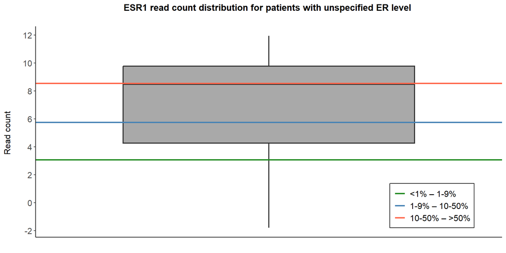

```r
# Final boxplot
ggplot(countsER[countsER$ER_level == "Unspecified", ], aes(x = ER_level, y = counts)) +
    geom_boxplot(fill = "darkgray", linewidth = 0.75) + labs(x = "", y = "Read count \n",
    title = "ESR1 read count distribution for patients with unspecified ER level \n",
    colour = NULL) + theme_classic() + theme(legend.position = c(0.85, 0.15), legend.background = element_rect(colour = "black",
    fill = "white"), legend.text = element_text(size = 12), plot.title = element_text(face = "bold",
    hjust = 0.5), axis.text = element_text(size = 12), axis.title = element_text(size = 12)) +
    theme(axis.line = element_line(color = "black"), axis.text.x = element_blank(),
        axis.ticks.x = element_blank()) + scale_y_continuous(breaks = seq(-2, 12,
    2)) + geom_hline(aes(yintercept = cutpts[1], color = "<1% – 1-9%"), linewidth = 1) +
    geom_hline(aes(yintercept = cutpts[2], colour = "1-9% – 10-50%"), linewidth = 1) +
    geom_hline(aes(yintercept = cutpts[3], colour = "10-50% – >50%"), linewidth = 1) +
    scale_color_manual(values = c(`10-50% – >50%` = "tomato", `1-9% – 10-50%` = "steelblue",
        `<1% – 1-9%` = "forestgreen"))
```

As we could already observe in the original boxplot, the “Unspecified” category appears very variable with values spreading across the entire expression range of other categories. It seems not feasible to reclassify these cases so we will keep them separate.